# Airbnb Pricing Analysis in Europe

Yacine Montacer

08/05/2023

## Introduction

For my end of studies mini-senior project, I found a dataset containing Airbnb rental data for European cities for over 51,000 listings. The dataset includes features such as the total listing price, room type, host status, amenities and location information which can be exploited to analyze these factors’ relation to the Airbnb prices. For more information see: https://www.kaggle.com/datasets/thedevastator/airbnb-price-determinants-in-europe?resource=download

We have data for several European cities for both weekdays & week-ends. So let’s first begin by importing all the different data into one aggregate set:

```r
# Create an empty data frame to store the combined data
combined_data <- data.frame()

# Define the list of cities and data types (weekdays and weekends)
cities <- c("amsterdam", "athens", "barcelona", "berlin", "budapest", "lisbon", "london", "paris", "rome", "vienna")
data_types <- c("weekdays", "weekends")

# Loop through each city and data type
for (city in cities) {
  for (data_type in data_types) {
    # Construct the file path for the CSV file
    file_path <- paste("data/", city, "_", data_type, ".csv", sep = "")

    # Read the CSV file into a data frame
    city_data <- read.csv(file_path)

    # Create variables to identify the city and data type
    city_data$city <- city
    city_data$data_type <- data_type

    # Combine the data for the current city and data type with the overall data
    combined_data <- rbind(combined_data, city_data)
  }
}

#display first lines of data
head(combined_data, 10)
```

```
##    X   realSum       room_type room_shared room_private person_capacity
## 1  0  194.0337    Private room       False         True               2
## 2  1  344.2458    Private room       False         True               4
## 3  2  264.1014    Private room       False         True               2
## 4  3  433.5294    Private room       False         True               4
## 5  4  485.5529    Private room       False         True               2
## 6  5  552.8086    Private room       False         True               3
## 7  6  215.1243    Private room       False         True               2
## 8  7 2771.3074 Entire home/apt       False        False               4
## 9  8 1001.8044 Entire home/apt       False        False               4
## 10 9  276.5215    Private room       False         True               2
##    host_is_superhost multi biz cleanliness_rating guest_satisfaction_overall
## 1              False     1   0                 10                         93
## 2              False     0   0                  8                         85
## 3              False     0   1                  9                         87
```

[output cut: 29 more lines]

Now let’s include the libraries we need to move forward:

```r
library(ggplot2)
library(dplyr)
library(tidyr)
```

Now let’s proceed with exploratory data analysis:

```r
# Summary statistics
summary(combined_data)
```

```
##        X           realSum          room_type         room_shared
##  Min.   :   0   Min.   :   34.78   Length:51707       Length:51707
##  1st Qu.: 646   1st Qu.:  148.75   Class :character   Class :character
##  Median :1334   Median :  211.34   Mode  :character   Mode  :character
##  Mean   :1621   Mean   :  279.88
##  3rd Qu.:2382   3rd Qu.:  319.69
##  Max.   :5378   Max.   :18545.45
##  room_private       person_capacity host_is_superhost      multi
##  Length:51707       Min.   :2.000   Length:51707       Min.   :0.0000
##  Class :character   1st Qu.:2.000   Class :character   1st Qu.:0.0000
##  Mode  :character   Median :3.000   Mode  :character   Median :0.0000
##                     Mean   :3.162                      Mean   :0.2914
##                     3rd Qu.:4.000                      3rd Qu.:1.0000
##                     Max.   :6.000                      Max.   :1.0000
##       biz         cleanliness_rating guest_satisfaction_overall
##  Min.   :0.0000   Min.   : 2.000     Min.   : 20.00
##  1st Qu.:0.0000   1st Qu.: 9.000     1st Qu.: 90.00
##  Median :0.0000   Median :10.000     Median : 95.00
##  Mean   :0.3502   Mean   : 9.391     Mean   : 92.63
##  3rd Qu.:1.0000   3rd Qu.:10.000     3rd Qu.: 99.00
##  Max.   :1.0000   Max.   :10.000     Max.   :100.00
##     bedrooms           dist            metro_dist          attr_index
##  Min.   : 0.000   Min.   : 0.01504   Min.   : 0.002301   Min.   :  15.15
##  1st Qu.: 1.000   1st Qu.: 1.45314   1st Qu.: 0.248480   1st Qu.: 136.80
##  Median : 1.000   Median : 2.61354   Median : 0.413269   Median : 234.33
##  Mean   : 1.159   Mean   : 3.19129   Mean   : 0.681540   Mean   : 294.20
##  3rd Qu.: 1.000   3rd Qu.: 4.26308   3rd Qu.: 0.737840   3rd Qu.: 385.76
##  Max.   :10.000   Max.   :25.28456   Max.   :14.273577   Max.   :4513.56
##  attr_index_norm      rest_index      rest_index_norm         lng
##  Min.   :  0.9263   Min.   :  19.58   Min.   :  0.5928   Min.   :-9.2263
##  1st Qu.:  6.3809   1st Qu.: 250.85   1st Qu.:  8.7515   1st Qu.:-0.0725
##  Median : 11.4683   Median : 522.05   Median : 17.5422   Median : 4.8730
##  Mean   : 13.4238   Mean   : 626.86   Mean   : 22.7862   Mean   : 7.4261
##  3rd Qu.: 17.4151   3rd Qu.: 832.63   3rd Qu.: 32.9646   3rd Qu.:13.5188
##  Max.   :100.0000   Max.   :6696.16   Max.   :100.0000   Max.   :23.7860
##       lat            city            data_type
##  Min.   :37.95   Length:51707       Length:51707
##  1st Qu.:41.40   Class :character   Class :character
##  Median :47.51   Mode  :character   Mode  :character
##  Mean   :45.67
##  3rd Qu.:51.47
##  Max.   :52.64
```

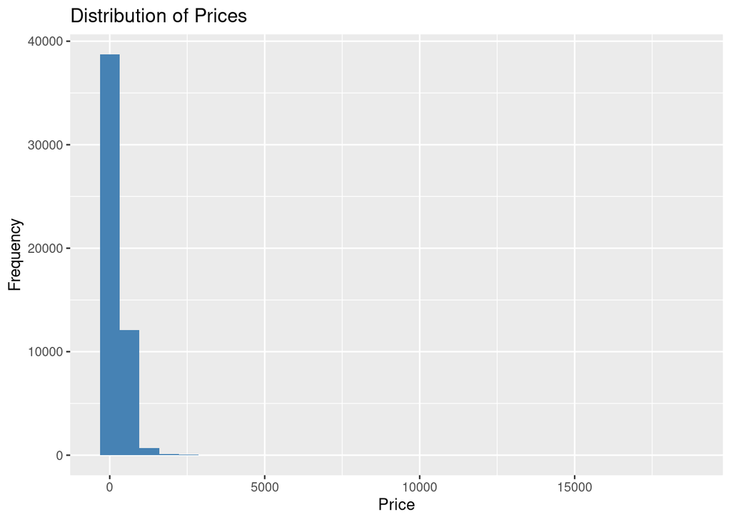

```r
# Histogram of price
ggplot(combined_data, aes(x = realSum)) +
  geom_histogram(fill = "steelblue", bins = 30) +
  labs(x = "Price", y = "Frequency", title = "Distribution of Prices")
```

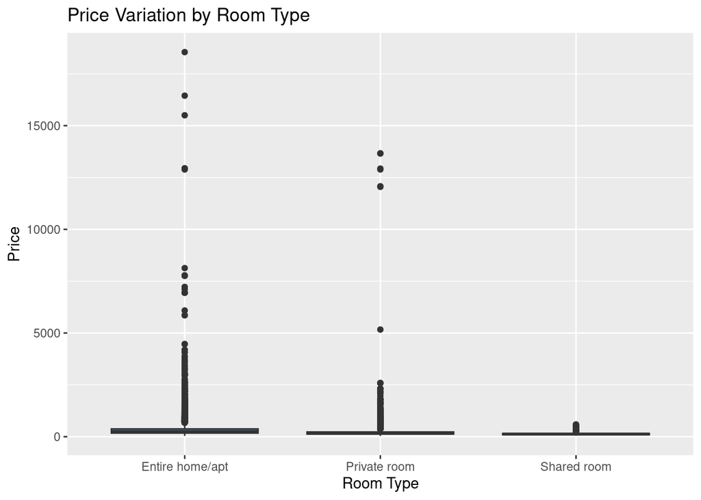

```r
# Boxplot of price by room type
ggplot(combined_data, aes(x = room_type, y = realSum)) +
  geom_boxplot(fill = "steelblue") +
  labs(x = "Room Type", y = "Price", title = "Price Variation by Room Type")
```

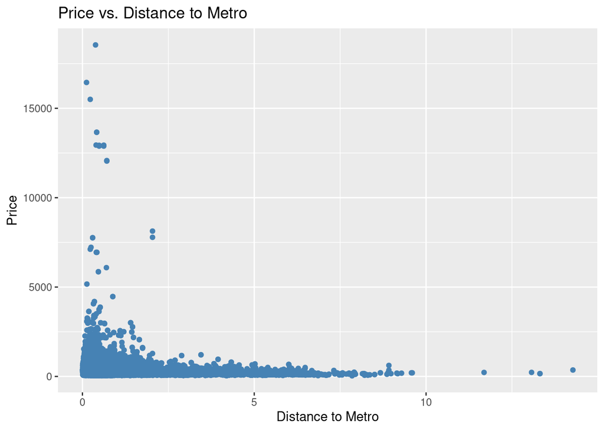

```r
# Scatterplot of price vs. distance to metro
ggplot(combined_data, aes(x = metro_dist, y = realSum)) +
  geom_point(color = "steelblue") +
  labs(x = "Distance to Metro", y = "Price", title = "Price vs. Distance to Metro")
```

let’s import additional libraries and proceed with a correlation matrix:

```r
# Load the necessary libraries
library(dplyr)
library(readr)
library(corrplot)
# Correlation matrix
cor_matrix <- cor(combined_data[, c("realSum", "person_capacity", "cleanliness_rating", "guest_satisfaction_overall", "bedrooms", "dist", "metro_dist", "rest_index", "attr_index", "rest_index_norm", "attr_index_norm", "lng", "lat", "biz")])
cor_matrix
```

```
##                                 realSum person_capacity cleanliness_rating
## realSum                     1.000000000     0.203076975       -0.006081830
## person_capacity             0.203076975     1.000000000        0.003256366
## cleanliness_rating         -0.006081830     0.003256366        1.000000000
## guest_satisfaction_overall -0.001887538     0.005180607        0.714045022
## bedrooms                    0.221653118     0.560626604        0.033488541
## dist                       -0.044725409    -0.128487570       -0.030201505
## metro_dist                 -0.061024568    -0.037266852        0.010440703
## rest_index                  0.134722476     0.037330433       -0.031928966
## attr_index                  0.178227526     0.028393864       -0.025322445
## rest_index_norm             0.144093710     0.038059011       -0.005994914
## attr_index_norm             0.292395979    -0.050486782       -0.075372187
## lng                        -0.173833185     0.146847677        0.120379088
## lat                         0.211805334    -0.168264601       -0.092502112
## biz                         0.037144015     0.110667827       -0.107309912
##                            guest_satisfaction_overall     bedrooms         dist
## realSum                                  -0.001887538  0.221653118 -0.044725409
## person_capacity                           0.005180607  0.560626604 -0.128487570
## cleanliness_rating                        0.714045022  0.033488541 -0.030201505
## guest_satisfaction_overall                1.000000000  0.047573402 -0.004178420
## bedrooms                                  0.047573402  1.000000000 -0.006262056
## dist                                     -0.004178420 -0.006262056  1.000000000
## metro_dist                                0.029788300  0.044430869  0.558063648
## rest_index                               -0.069318922 -0.014047168 -0.346652864
## attr_index                               -0.050623918 -0.011734991 -0.363087842
## rest_index_norm                          -0.008765411 -0.057725996 -0.467791424
## attr_index_norm                          -0.074146443 -0.063773403 -0.242861861
## lng                                       0.156078627  0.013688466 -0.147423787
## lat                                      -0.033957178 -0.104694400  0.405877740
## biz                                      -0.208159566 -0.026740577 -0.164766510
##                             metro_dist  rest_index  attr_index rest_index_norm
## realSum                    -0.06102457  0.13472248  0.17822753     0.144093710
## person_capacity            -0.03726685  0.03733043  0.02839386     0.038059011
## cleanliness_rating          0.01044070 -0.03192897 -0.02532244    -0.005994914
## guest_satisfaction_overall  0.02978830 -0.06931892 -0.05062392    -0.008765411
## bedrooms                    0.04443087 -0.01404717 -0.01173499    -0.057725996
## dist                        0.55806365 -0.34665286 -0.36308784    -0.467791424
## metro_dist                  1.00000000 -0.13887636 -0.16800996    -0.259653639
## rest_index                 -0.13887636  1.00000000  0.85022867     0.617969809
## attr_index                 -0.16800996  0.85022867  1.00000000     0.544402582
## rest_index_norm            -0.25965364  0.61796981  0.54440258     1.000000000
## attr_index_norm            -0.21958700  0.52762336  0.71484733     0.472142673
## lng                        -0.06950628 -0.17670437 -0.12694183    -0.134730533
## lat                         0.08642446 -0.11316294 -0.05243771     0.023697541
## biz                        -0.10915324  0.13774652  0.11473176     0.083999345
##                            attr_index_norm         lng         lat         biz
## realSum                         0.29239598 -0.17383319  0.21180533  0.03714402
## person_capacity                -0.05048678  0.14684768 -0.16826460  0.11066783
## cleanliness_rating             -0.07537219  0.12037909 -0.09250211 -0.10730991
## guest_satisfaction_overall     -0.07414644  0.15607863 -0.03395718 -0.20815957
## bedrooms                       -0.06377340  0.01368847 -0.10469440 -0.02674058
## dist                           -0.24286186 -0.14742379  0.40587774 -0.16476651
## metro_dist                     -0.21958700 -0.06950628  0.08642446 -0.10915324
## rest_index                      0.52762336 -0.17670437 -0.11316294  0.13774652
## attr_index                      0.71484733 -0.12694183 -0.05243771  0.11473176
## rest_index_norm                 0.47214267 -0.13473053  0.02369754  0.08399934
## attr_index_norm                 1.00000000 -0.22159067  0.43523724  0.09372042
## lng                            -0.22159067  1.00000000 -0.15921358 -0.08894311
## lat                             0.43523724 -0.15921358  1.00000000 -0.12643305
## biz                             0.09372042 -0.08894311 -0.12643305  1.00000000
```

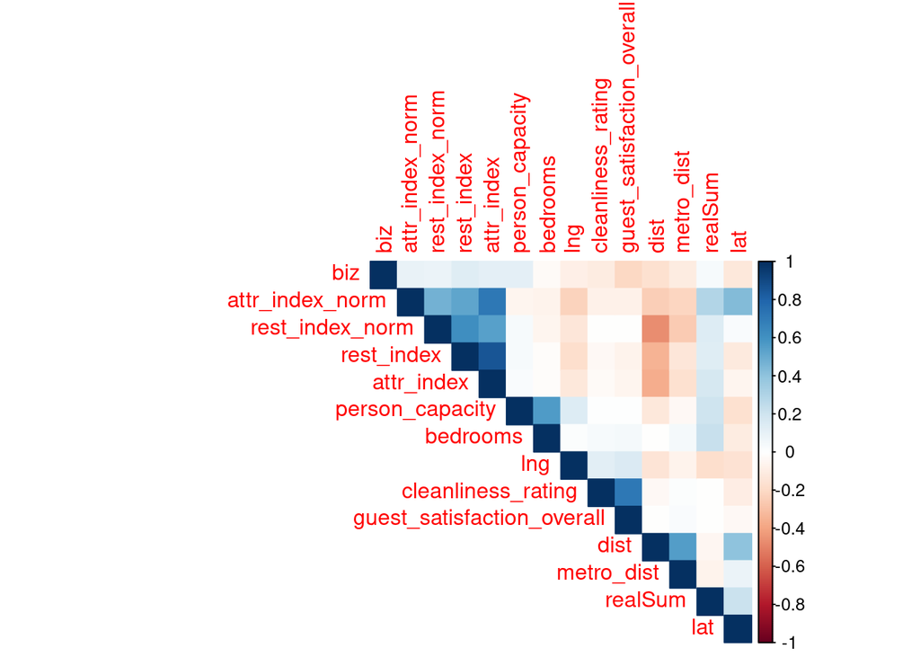

```r
# Visualize the correlation matrix
corrplot(cor_matrix, method = "color", type = "upper", order = "hclust")
```

Seeing the variables that correlate with the price, we can try to create a linear regression model:

```r
library(tidyverse)
library(caret)
#model
lm_model <- lm(realSum ~ person_capacity + bedrooms + attr_index_norm + rest_index_norm + guest_satisfaction_overall + dist + metro_dist, data = combined_data)

#summarize LM model
summary(lm_model)
```

```
##
## Call:
## lm(formula = realSum ~ person_capacity + bedrooms + attr_index_norm +
##     rest_index_norm + guest_satisfaction_overall + dist + metro_dist,
##     data = combined_data)
##
## Residuals:
##     Min      1Q  Median      3Q     Max
## -1070.0   -95.7   -29.8    48.0 18420.1
##
## Coefficients:
##                              Estimate Std. Error t value Pr(>|t|)
## (Intercept)                -154.31967   14.87484 -10.375  < 2e-16 ***
## person_capacity              32.95566    1.24926  26.380  < 2e-16 ***
## bedrooms                     89.60940    2.56769  34.899  < 2e-16 ***
## attr_index_norm              10.28557    0.15513  66.301  < 2e-16 ***
## rest_index_norm               0.62139    0.09295   6.685 2.33e-11 ***
## guest_satisfaction_overall    0.50381    0.14874   3.387 0.000707 ***
## dist                         11.32038    0.73483  15.406  < 2e-16 ***
## metro_dist                  -12.99318    1.87526  -6.929 4.30e-12 ***
## ---
## Signif. codes:  0 '***' 0.001 '**' 0.01 '*' 0.05 '.' 0.1 ' ' 1
##
## Residual standard error: 301 on 51699 degrees of freedom
## Multiple R-squared:  0.1577, Adjusted R-squared:  0.1575
## F-statistic:  1382 on 7 and 51699 DF,  p-value: < 2.2e-16
```

Since the linear model is inadequate with a low R squared. I chose to implement a random forest algorithm to see if I can find non-linear relationships between pricing and the exploratory variables

```r
# Load the required libraries
library(randomForest)
library(caret)

# Define your predictors (independent variables)
predictors <- c(
  "room_shared",
  "room_private",
  "person_capacity",
  "host_is_superhost",
  "multi",
  "biz",
  "cleanliness_rating",
  "guest_satisfaction_overall",
  "bedrooms",
  "dist",
  "metro_dist",
  "attr_index",
  "attr_index_norm",
  "rest_index",
  "rest_index_norm",
  "lng",
  "lat"
)

# Create a data frame with only the selected predictors and the target variable (price)
data_subset <- combined_data[, c(predictors, "realSum")]

# Split the data into a training set and a testing set
set.seed(123)  # for reproducibility
sample_index <- sample(1:nrow(data_subset), 0.7 * nrow(data_subset))
train_data <- data_subset[sample_index, ]
test_data <- data_subset[-sample_index, ]

# Train the Random Forest model
rf_model <- randomForest(realSum ~ ., data = train_data, ntree = 500)

# Make predictions on the test set
predictions <- predict(rf_model, test_data)

# Evaluate the model
rmse <- sqrt(mean((test_data$realSum - predictions)^2))
mae <- mean(abs(test_data$realSum - predictions))

# Print the evaluation metrics
print(paste("Root Mean Squared Error (RMSE):", rmse))
```

```
## [1] "Root Mean Squared Error (RMSE): 245.974459183244"
```

```r
print(paste("Mean Absolute Error (MAE):", mae))
```

```
## [1] "Mean Absolute Error (MAE): 58.3957196796319"
```

```r
# Calculate R-squared
r_squared <- 1 - (sum((test_data$realSum - predictions)^2) / sum((test_data$realSum - mean(test_data$realSum))^2))
print(paste("R-squared (R²):", r_squared))
```

```
## [1] "R-squared (R²): 0.380843915360358"
```

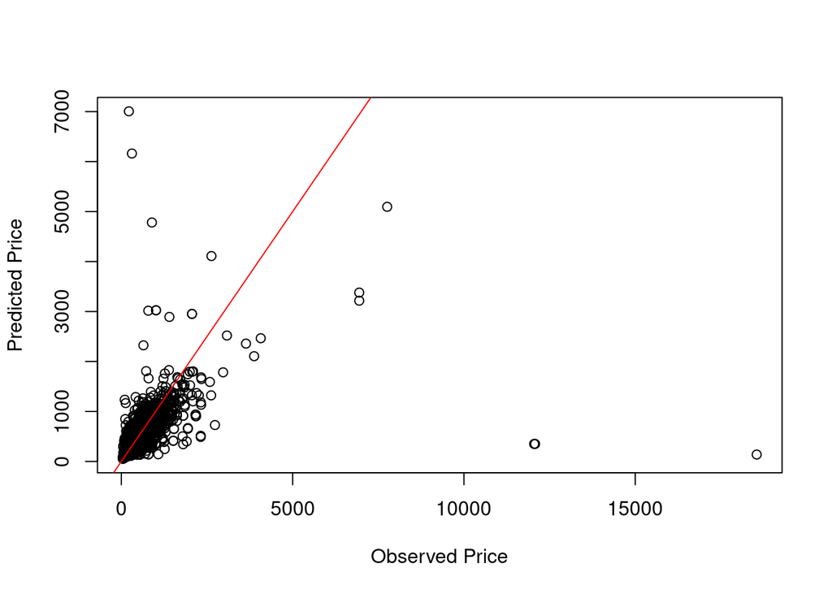

```r
# Create a scatter plot of observed vs. predicted values
plot(test_data$realSum, predictions, xlab = "Observed Price", ylab = "Predicted Price")
abline(0, 1, col = "red")  # Add a diagonal line for reference
```

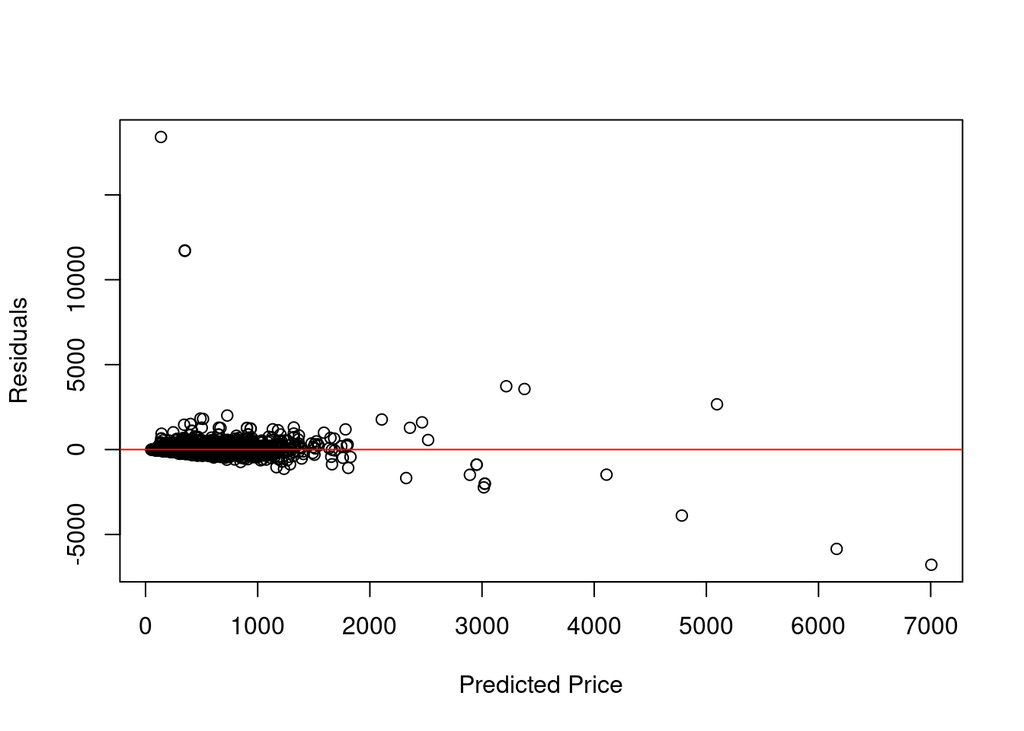

```r
# Create residual plot
residuals <- test_data$realSum - predictions
plot(predictions, residuals, xlab = "Predicted Price", ylab = "Residuals")
abline(h = 0, col = "red")  # Add a horizontal line at zero for reference
```

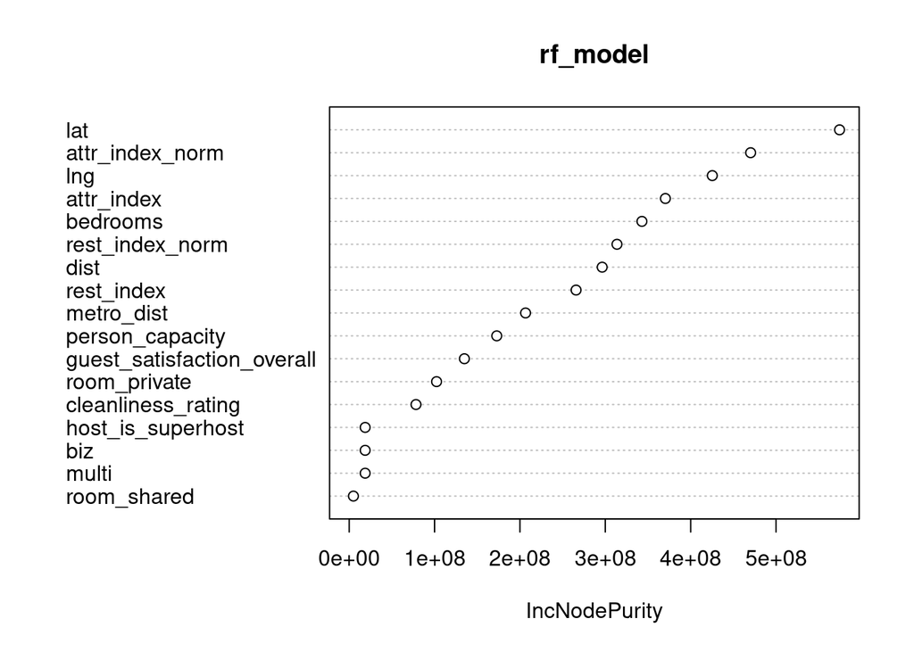

```r
# Visualize feature importance
varImpPlot(rf_model)
```